# Taller de la Clase 6

Repaso integrador de las clases 1 a 5

Juan David Garro Arboleda — jgarro@unal.edu.co

Mariana Castano Celis — mcastanoce@unal.edu.co

2026-09-20

# Guía de trabajo

Este documento desarrolla el código de ambas rutas. Las cajas **ESCRIBIR AQUÍ** y las celdas **[Completar]** están reservadas para las respuestas de los autores. Los comentarios del código describen las operaciones; las interpretaciones se escriben en los espacios correspondientes.

# 1. Utilidades y decisiones de implementación

# 2. Estación A. Diagnóstico: cuatro series, cuatro patrones

```r
# Se conservan los objetos ts originales para mostrar años en los gráficos.
# as.numeric se usa solo cuando interesa la posición de cada observación.
series_A <- list(
  "Nivel del lago Hurón" = LakeHuron,
  "Temperatura en Nottingham" = nottem,
  "Población de Australia" = austres,
  "Muertes accidentales" = USAccDeaths
)
```

## A.1. Gráficas, correlogramas y autocorrelaciones

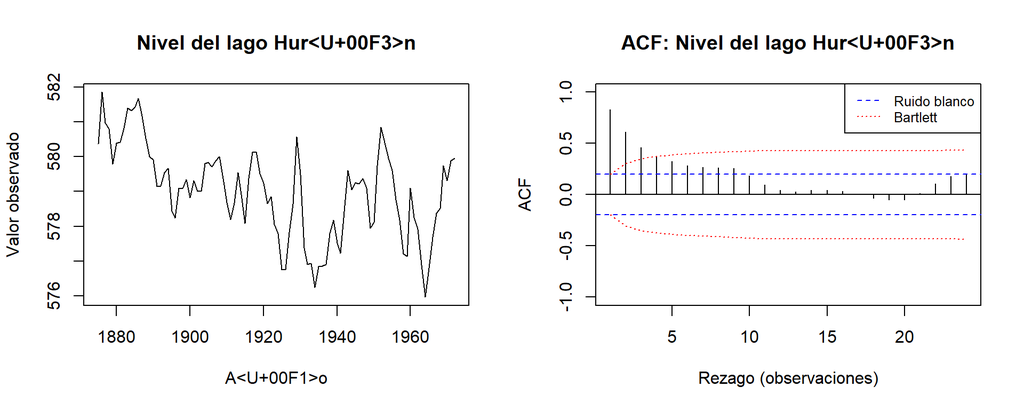

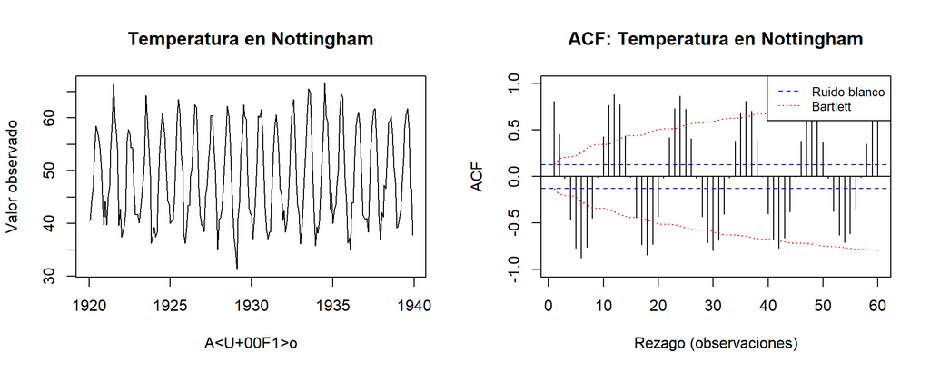

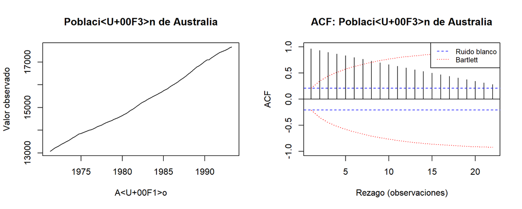

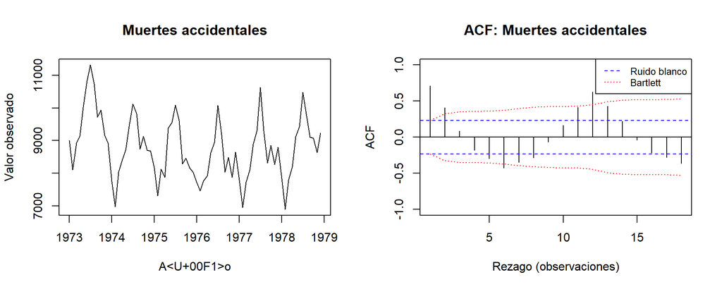

```r
tabla_A <- data.frame()
for (nombre in names(series_A)) {
  serie <- series_A[[nombre]]
  n <- length(serie)
  s <- frequency(serie)
  # mfrow organiza la serie a la izquierda y su ACF a la derecha.
  par(mfrow = c(1, 2))
  plot(serie, main = nombre, xlab = "Año", ylab = "Valor observado")
  graficar_acf(serie, floor(n / 4), paste("ACF:", nombre))
  r <- as.numeric(stats::acf(as.numeric(serie),
                             lag.max = 2 * s, plot = FALSE)$acf)
  tabla_A <- rbind(tabla_A, data.frame(
    Serie = nombre, T = n, s = s, r1 = r[2], rs = r[s + 1],
    r2s = r[2 * s + 1]
  ))
}
```

```r
par(mfrow = c(1, 1))
mostrar_tabla(tabla_A)
```

| Serie | T | s | r1 | rs | r2s |
| --- | --- | --- | --- | --- | --- |
| Nivel del lago Hurón | 98 | 1 | 0.8319 | 0.8319 | 0.6099 |
| Temperatura en Nottingham | 240 | 12 | 0.8077 | 0.8843 | 0.8662 |
| Población de Australia | 89 | 4 | 0.9666 | 0.8665 | 0.7317 |
| Muertes accidentales | 72 | 12 | 0.7075 | 0.6286 | 0.4503 |

Para la serie anual, s = 1 representa su frecuencia; no implica afirmar estacionalidad anual.

## A.2. Ljung–Box con 24 rezagos

**Hipótesis.**  
$H_0: \rho_1 = \rho_2 = \cdots = \rho_{24} = 0$ (la serie es ruido blanco hasta el rezago 24) contra $H_1:$ algún $\rho_k \neq 0$. El estadístico es

que bajo $H_0$ se distribuye aproximadamente $\chi^2_m$ (aquí $m=24$, sin descontar parámetros porque se prueba la serie cruda, no residuos).

**Significancia y regla.**  
Con $\alpha = 0{,}05$, el valor crítico es $\chi^2_{24;\,0{,}95} = 36{,}42$. Se rechaza $H_0$ si $Q > 36{,}42$ (equivalentemente, si valor_p $< 0.05$).

**¿Por qué rechaza en las cuatro?**  
Los cuatro $Q$ (203, 2342, 953 y 237) superan por completo ese umbral y los cuatro valor_p son prácticamente cero. Ninguna de las cuatro series es ruido blanco.

**¿Por qué no distingue los patrones?**  
$Q$ es una suma de cuadrados de los $r_k$: acumula magnitud sin registrar en qué rezagos se concentra la autocorrelación. Un $r_1$ grande (tendencia) y un $r_{12}$ grande (estacionalidad) contribuyen igual a $Q$. La prueba contesta “¿queda estructura?”, no “¿qué tipo de estructura queda?” — esa segunda pregunta la responde la forma del correlograma (Ejercicios A.1, A.3), no el valor agregado de Ljung–Box.

```r
tabla_A_ljung <- data.frame()
for (nombre in names(series_A)) {
  tabla_A_ljung <- rbind(tabla_A_ljung, cbind(
    Serie = nombre, resultado_ljung(series_A[[nombre]], m = 24)
  ))
}
mostrar_tabla(tabla_A_ljung)
```

| Serie | n | m | parametros_descontados | gl | Q | valor_p |
| --- | --- | --- | --- | --- | --- | --- |
| Nivel del lago Hurón | 98 | 24 | 0 | 24 | 203.237 | < 1e-12 |
| Temperatura en Nottingham | 240 | 24 | 0 | 24 | 2342.383 | < 1e-12 |
| Población de Australia | 89 | 24 | 0 | 24 | 953.448 | < 1e-12 |
| Muertes accidentales | 72 | 24 | 0 | 24 | 237.019 | < 1e-12 |

## A.3. Tabla de decisión

[output not shown]

## A.4 — Dos decaimientos lentos, dos causas

Tanto la **Población de Australia** (`austres`) como el **Nivel del lago Hurón** (`LakeHuron`) muestran un decaimiento lento del correlograma, pero **las causas son distintas**:

- **Decaimiento lento por tendencia:** Población de Australia.
- **Decaimiento lento sin tendencia:** Nivel del lago Hurón.

### Justificación sin correlograma (argumento de incrementos)

Una tendencia es una **dirección sostenida**: si existe, casi todos los incrementos

$$\Delta y_t = y_t - y_{t-1}$$

comparten signo. Este argumento permite distinguir los dos casos **sin mirar el correlograma**, solo a partir del comportamiento de las primeras diferencias.

- En `austres`, el **100 % de los incrementos trimestrales es positivo** y la racha monótona más larga cubre las **88 observaciones completas**: la serie **nunca retrocede**. El nivel crece sin pausa, lo que es la firma inequívoca de una tendencia determinista o estocástica sostenida.
- En `LakeHuron`, los incrementos se reparten casi mitad y mitad (**48,5 % positivos**) y la racha monótona más larga es de **apenas 7 años**. El nivel sube y baja y **vuelve sobre sí mismo**: no hay una dirección dominante, solo fluctuaciones de nivel.

### Interpretación

El correlograma de Hurón decae lentamente **no porque haya una dirección**, sino porque **el nivel es persistente**: lo que está alto este año tiende a seguir alto el próximo, simplemente porque el agua no se evapora de un año a otro. El de Australia decae lentamente **porque el nivel crece sin parar**.

### Consecuencia práctica

La consecuencia práctica es distinta para cada serie:

- En **Australia**, extrapolar una **recta** (o ajustar un modelo con tendencia) es razonable: los incrementos consistentemente positivos respaldan la idea de que la dirección continuará.
- En el **lago Hurón**, **no**: ahí se pronostica con **métodos de nivel** (medias móviles, suavizamiento exponencial simple, ARMA sobre la serie sin diferenciar), no con métodos de tendencia. Extrapolar una recta sobre una serie que oscila alrededor de una media estable produce pronósticos sesgados a largo plazo.

# 3. Estación B. Protocolo completo para ambas rutas

```r
# Cada entrada contiene la serie, su frecuencia, sus orígenes y candidatos.
# Los orígenes son índices de la última observación conocida.
# 200:239 proporciona 40 pronósticos de Nottingham; 80:107, 28 de UKgas.
# La segunda selección permite también consultar el tramo citado en C.4.
rutas <- list(
  ruta1 = list(
    serie = nottem, s = 12, origenes = 200:239,
    metodos = c("Ingenuo estacional", "Medias estacionales",
                "Tendencia y ficticias", "HW aditivo")
  ),
  ruta2 = list(
    serie = UKgas, s = 4, origenes = 80:107,
    metodos = c("Ingenuo estacional", "Tendencia y ficticias",
                "Log tendencia y ficticias", "HW aditivo", "HW multiplicativo")
  )
)
evaluaciones <- list()
```

## Paso 1. Graficar y nombrar el patrón

### Ruta 1. Temperatura mensual de Nottingham

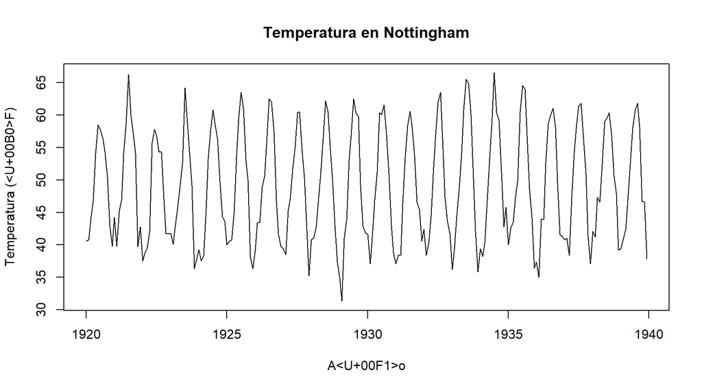

```r
# Se seleccionan los datos de esta ruta y se conserva su calendario.
ruta <- rutas$ruta1
serie <- ruta$serie
y <- as.numeric(serie)
s <- ruta$s
plot(serie, main = "Temperatura en Nottingham",
     xlab = "Año", ylab = "Temperatura (°F)")
```

#### Componentes de la serie (Temperatura en Nottingham)

| Componente | ¿Se observa? | Evidencia |
| --- | --- | --- |
| Nivel | Sí | Oscila alrededor de 49 °F de forma estable durante los veinte años. |
| Tendencia | No a simple vista | La serie no muestra una tendecia visible. |
| Estacionalidad | Sí, dominante | Ciclo anual muy regular, de unos 23 °F entre el mes más frío y el más cálido, repetido con la misma forma cada doce meses. |
| Ciclo | No a simple vista | No hay oscilaciones con peridos superiores a un año. |
| Episodios atípicos | Prácticamente ninguno | Algún invierno algo más suave o verano algo más fresco, pero dentro del rango habitual; no se aprecian quiebres ni valores extremos aislados. |

### Ruta 2. Consumo trimestral de gas del Reino Unido

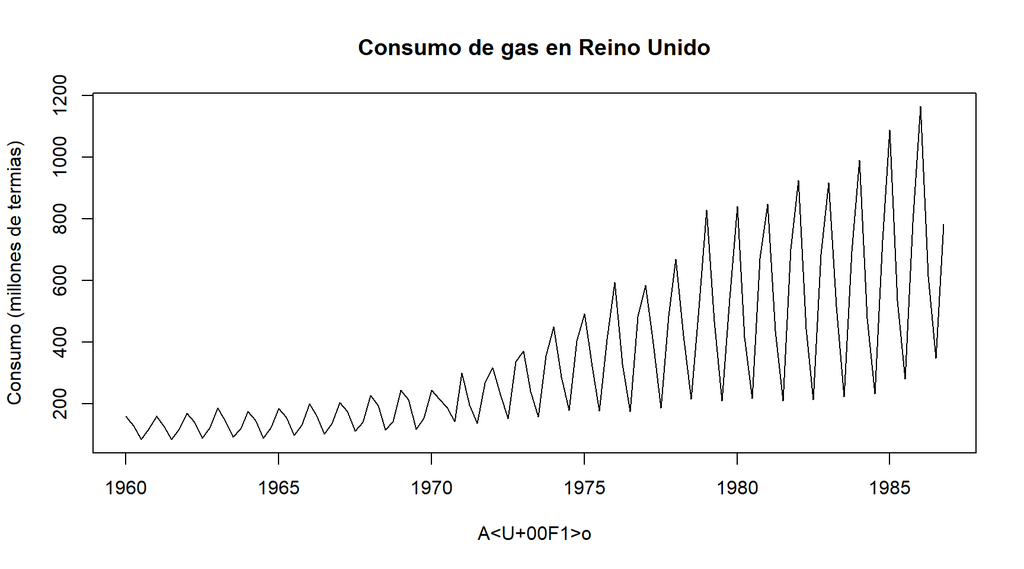

| Componente | ¿Se observa? | Evidencia |
| --- | --- | --- |
| Nivel | Sí; cambia con el tiempo | El consumo medio pasa de valores cercanos a 120 millones de termias al inicio a valores superiores a 600 millones hacia el final. |
| Tendencia | Sí, creciente | La trayectoria general aumenta durante todo el período y el crecimiento se vuelve más pronunciado desde mediados de la década de 1970. |
| Estacionalidad | Sí, dominante | Los máximos y mínimos se repiten cada cuatro trimestres; además, la amplitud estacional crece a medida que aumenta el nivel. |
| Ciclo | No se observa claramente | Fuera de la oscilación trimestral, la gráfica no muestra movimientos recurrentes de varios años alrededor de la tendencia. |
| Episodios atípicos | No se observan claramente | Los picos y valles siguen el patrón estacional creciente y no aparece un valor aislado que rompa de forma evidente la dinámica de la serie. |

```r
# Se seleccionan los datos de esta ruta y se conserva su calendario.
ruta <- rutas$ruta2
serie <- ruta$serie
y <- as.numeric(serie)
s <- ruta$s
plot(serie, main = "Consumo de gas en Reino Unido",
     xlab = "Año", ylab = "Consumo (millones de termias)")
```

#### Procedimiento adicional de la ruta 2: nivel y amplitud anual

```r
# Cada fila de la matriz guarda los cuatro trimestres de un año.
# rowMeans obtiene el nivel medio; apply con MARGIN = 1 recorre las filas.
datos_anuales <- matrix(y, ncol = s, byrow = TRUE)
resumen_anual <- data.frame(
  Anio = unique(floor(as.numeric(time(serie)))),
  Nivel = rowMeans(datos_anuales),
  Amplitud = apply(datos_anuales, MARGIN = 1,
                  FUN = function(valores) max(valores) - min(valores))
)
mostrar_tabla(resumen_anual)
```

| Anio | Nivel | Amplitud |
| --- | --- | --- |
| 1960 | 123.675 | 75.3 |
| 1961 | 121.675 | 75.3 |
| 1962 | 130.900 | 80.0 |
| 1963 | 136.100 | 94.4 |
| 1964 | 134.100 | 86.4 |
| 1965 | 142.900 | 86.4 |
| 1966 | 150.100 | 97.6 |
| 1967 | 158.500 | 92.8 |
| 1968 | 170.100 | 112.0 |
| 1969 | 182.900 | 126.4 |
| 1970 | 198.100 | 102.4 |
| 1971 | 225.325 | 164.9 |
| 1972 | 258.950 | 184.1 |
| 1973 | 281.350 | 212.9 |
| 1974 | 329.800 | 270.6 |
| 1975 | 350.200 | 313.8 |
| 1976 | 395.825 | 417.8 |
| 1977 | 413.025 | 397.0 |
| 1978 | 453.850 | 453.1 |
| 1979 | 511.900 | 618.0 |
| 1980 | 535.900 | 622.8 |
| 1981 | 549.100 | 638.8 |
| 1982 | 566.700 | 710.8 |
| 1983 | 587.925 | 693.2 |
| 1984 | 607.550 | 755.7 |
| 1985 | 672.775 | 805.2 |
| 1986 | 726.800 | 816.5 |

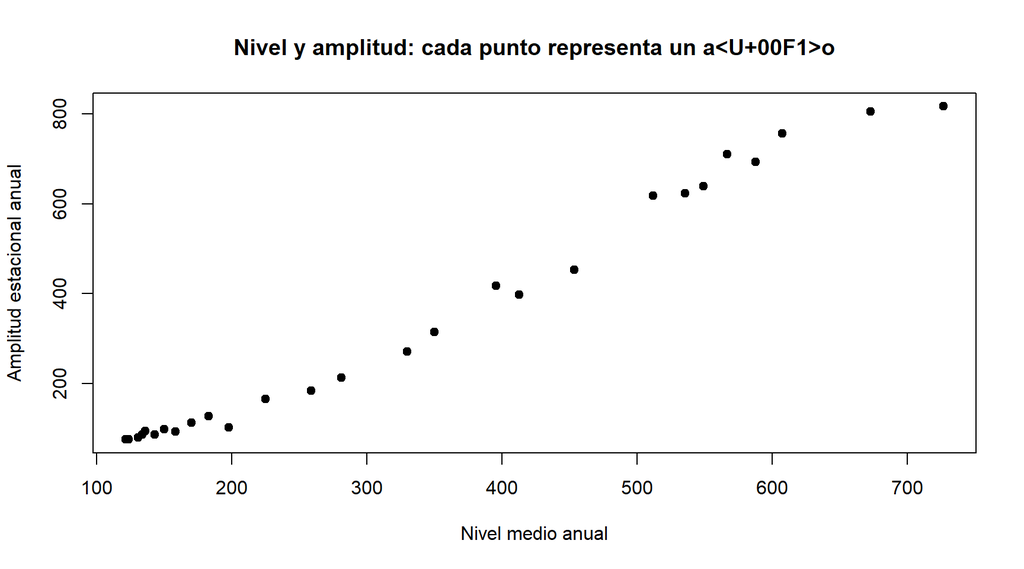

```r
plot(resumen_anual$Nivel, resumen_anual$Amplitud, pch = 19,
     xlab = "Nivel medio anual", ylab = "Amplitud estacional anual",
     main = "Nivel y amplitud: cada punto representa un año")
```

```r
mostrar_tabla(data.frame(Correlacion = cor(resumen_anual$Nivel,
                                          resumen_anual$Amplitud)))
```

| Correlacion |
| --- |
| 0.9917 |

**Ruta 2, escala**

- **Decisión:** La escala de la ruta 2 es multiplicativa.
- **Justificación:** La amplitud estacional aumenta con el nivel medio y su correlación es positiva y muy alta ($0{,}99$). Esto indica que las oscilaciones estacionales crecen proporcionalmente con el nivel de la serie.

## Paso 2. Correlograma y prueba

### Ruta 1. Temperatura mensual de Nottingham

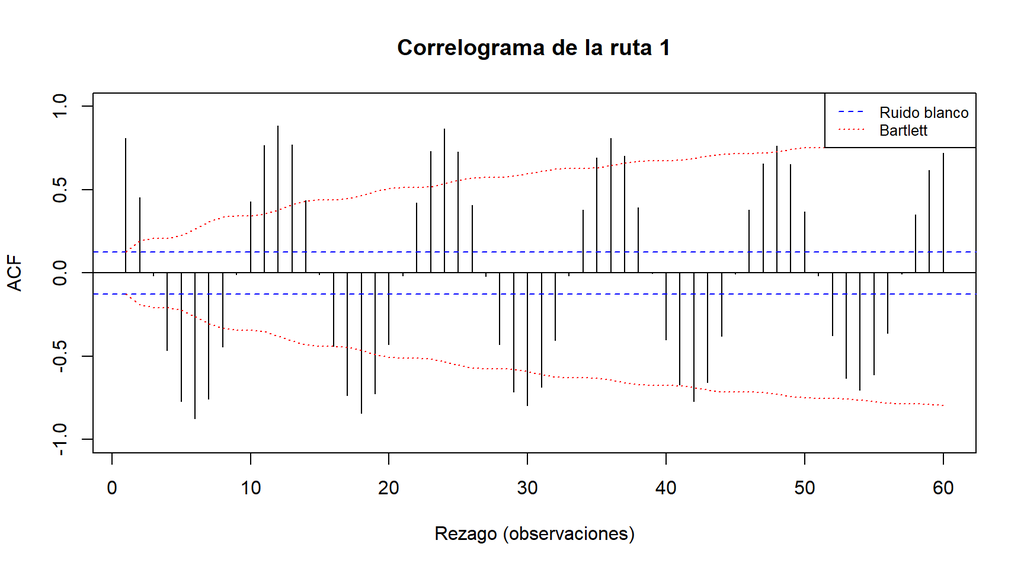

```r
# Se recuperan los datos de la ruta 1 para avanzar en paralelo por pasos.
ruta <- rutas$ruta1
serie <- ruta$serie
y <- as.numeric(serie)
s <- ruta$s

graficar_acf(y, floor(length(y) / 4), "Correlograma de la ruta 1")
```

```r
# Se solicitan cuatro múltiplos del período estacional.
# Se suma 1 para saltar la posición del rezago cero.
rezagos <- s * 1:4
r <- as.numeric(stats::acf(y, lag.max = 4 * s, plot = FALSE)$acf)
mostrar_tabla(data.frame(Rezago = rezagos, ACF = r[rezagos + 1]))
```

| Rezago | ACF |
| --- | --- |
| 12 | 0.8843 |
| 24 | 0.8662 |
| 36 | 0.8097 |
| 48 | 0.7618 |

```r
mostrar_tabla(resultado_ljung(y, m = 4 * s))
```

| n | m | parametros_descontados | gl | Q | valor_p |
| --- | --- | --- | --- | --- | --- |
| 240 | 48 | 0 | 48 | 4491.79 | < 1e-12 |

**Ruta 1, paso 2**

#### Ljung–Box con 48 rezagos

#### Hipótesis, significancia y regla

$H_0:$ `nottem` es ruido blanco hasta el rezago $m = 48$, contra $H_1:$ no lo es. Con $\alpha = 0{,}05$ se rechaza si

$$Q > \chi^2_{48;\,0{,}95} = 65{,}17.$$

#### Interpretación de Ljung–Box

$Q = 4491{,}8$ con valor_p $< 10^{-12}$: se rechaza $H_0$ con enorme margen. Era esperable — la serie tiene un ciclo estacional casi determinístico, lejos de cualquier noción de ruido blanco.

#### ¿Decaen o se mantienen los picos?

Se mantienen:

$$r_{12} = 0{,}884,\quad r_{24} = 0{,}866,\quad r_{36} = 0{,}810,\quad
r_{48} = 0{,}762.$$

La caída entre el primer y el último pico es de apenas **14 %**, y ese poco que cae es el efecto de borde de tener menos pares disponibles al calcular rezagos altos con $T = 240$ fijo, no un decaimiento real de la dependencia estacional.

#### ¿Qué distingue una serie de tipo II de una de tipo IV?

En una serie de **tipo II**, el correlograma oscila alrededor de cero con período $s$: aparecen picos positivos en $s, 2s, 3s, \dots$ y valores negativos en los rezagos intermedios. En `nottem`, por ejemplo, $r_6\approx-0{,}88$ es casi el reflejo de $r_{12}$.

En una serie de **tipo IV**, la tendencia desplaza el correlograma hacia valores positivos. Los picos estacionales siguen presentes, pero aparecen sobre un decaimiento lento y los rezagos intermedios no suelen cruzar por debajo de cero. Por eso `nottem` representa el tipo II, mientras que `UKgas` representa el tipo IV.

### Ruta 2. Consumo trimestral de gas del Reino Unido

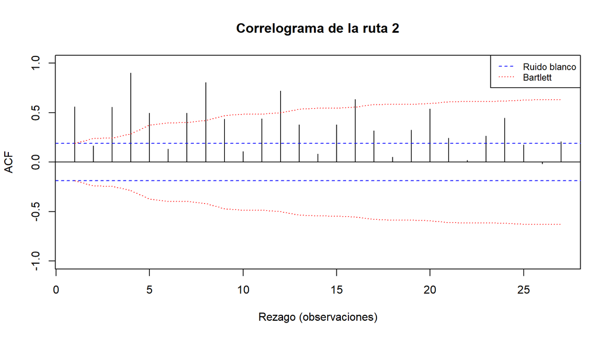

```r
# Se recuperan los datos de la ruta 2 para avanzar en paralelo por pasos.
ruta <- rutas$ruta2
serie <- ruta$serie
y <- as.numeric(serie)
s <- ruta$s

graficar_acf(y, floor(length(y) / 4), "Correlograma de la ruta 2")
```

```r
# Se solicitan cuatro múltiplos del período estacional.
# Se suma 1 para saltar la posición del rezago cero.
rezagos <- s * 1:4
r <- as.numeric(stats::acf(y, lag.max = 4 * s, plot = FALSE)$acf)
mostrar_tabla(data.frame(Rezago = rezagos, ACF = r[rezagos + 1]))
```

| Rezago | ACF |
| --- | --- |
| 4 | 0.9015 |
| 8 | 0.8056 |
| 12 | 0.7196 |
| 16 | 0.6334 |

```r
mostrar_tabla(resultado_ljung(y, m = 4 * s))
```

| n | m | parametros_descontados | gl | Q | valor_p |
| --- | --- | --- | --- | --- | --- |
| 108 | 16 | 0 | 16 | 503.3 | < 1e-12 |

**Ruta 2, paso 2**

- **Hipótesis y regla:** $H_0$ establece que no hay autocorrelación hasta el rezago 16. Con $\alpha=0{,}05$, se rechaza si $Q>\chi^2_{16;0{,}95}=26{,}30$ o si $p<0{,}05$.
- **Ljung–Box:** Como $Q=503{,}3$ y $p<10^{-12}$, se rechaza $H_0$; la serie presenta una fuerte dependencia temporal.
- **Picos estacionales:** Decaen gradualmente, pero permanecen altos: $r_4=0{,}902$, $r_8=0{,}806$, $r_{12}=0{,}720$ y $r_{16}=0{,}633$.
- **Tipos II y IV:** El tipo II oscila alrededor de cero; el tipo IV mantiene autocorrelaciones positivas con decaimiento lento por la tendencia. `UKgas` corresponde al **tipo IV**.

## Paso 3. Partir la muestra

### Ruta 1. Temperatura mensual de Nottingham

```r
# Se recuperan los datos de la ruta 1 para avanzar en paralelo por pasos.
ruta <- rutas$ruta1
serie <- ruta$serie
y <- as.numeric(serie)
s <- ruta$s

# El origen o usa los primeros o datos y evalúa exclusivamente el dato o+1.
origenes <- ruta$origenes
mostrar_tabla(data.frame(
  Primer_origen = min(origenes), Ultimo_origen = max(origenes),
  Numero_origenes = length(origenes), Horizonte = 1,
  Primer_dato_evaluado = min(origenes) + 1,
  Ultimo_dato_evaluado = max(origenes) + 1
))
```

| Primer_origen | Ultimo_origen | Numero_origenes | Horizonte | Primer_dato_evaluado | Ultimo_dato_evaluado |
| --- | --- | --- | --- | --- | --- |
| 200 | 239 | 40 | 1 | 201 | 240 |

**Ruta 1, paso 3**

Se utilizan los orígenes 200 a 239. En cada origen se ajustan los métodos únicamente con las observaciones disponibles hasta esa posición y se pronostica el dato siguiente. Así se obtienen 40 evaluaciones de horizonte uno, desde la observación 201 hasta la 240, sin usar información futura.

### Ruta 2. Consumo trimestral de gas del Reino Unido

```r
# Se recuperan los datos de la ruta 2 para avanzar en paralelo por pasos.
ruta <- rutas$ruta2
serie <- ruta$serie
y <- as.numeric(serie)
s <- ruta$s

# El origen o usa los primeros o datos y evalúa exclusivamente el dato o+1.
origenes <- ruta$origenes
mostrar_tabla(data.frame(
  Primer_origen = min(origenes), Ultimo_origen = max(origenes),
  Numero_origenes = length(origenes), Horizonte = 1,
  Primer_dato_evaluado = min(origenes) + 1,
  Ultimo_dato_evaluado = max(origenes) + 1
))
```

| Primer_origen | Ultimo_origen | Numero_origenes | Horizonte | Primer_dato_evaluado | Ultimo_dato_evaluado |
| --- | --- | --- | --- | --- | --- |
| 80 | 107 | 28 | 1 | 81 | 108 |

**Ruta 2, paso 3**

Se utilizan los orígenes 80 a 107. Cada método recibe únicamente los datos observados hasta el origen y pronostica el trimestre siguiente. El esquema produce 28 evaluaciones de horizonte uno, desde la observación 81 hasta la 108, manteniendo la misma ventana de comparación para todos los métodos.

## Paso 4. Ajustar candidatos en cada origen

### Ruta 1. Temperatura mensual de Nottingham

```r
# Se recuperan los datos de la ruta 1 para avanzar en paralelo por pasos.
ruta <- rutas$ruta1
serie <- ruta$serie
y <- as.numeric(serie)
s <- ruta$s
origenes <- ruta$origenes

# evaluar_ruta reestima todos los candidatos en cada origen.
# Los resultados quedan guardados para comparar, validar y pronosticar.
evaluaciones$ruta1 <- evaluar_ruta(y, s, origenes, ruta$metodos)
evaluacion <- evaluaciones$ruta1
mostrar_tabla(data.frame(Metodo = ruta$metodos))
```

| Metodo |
| --- |
| Ingenuo estacional |
| Medias estacionales |
| Tendencia y ficticias |
| HW aditivo |

### Ruta 2. Consumo trimestral de gas del Reino Unido

```r
# Se recuperan los datos de la ruta 2 para avanzar en paralelo por pasos.
ruta <- rutas$ruta2
serie <- ruta$serie
y <- as.numeric(serie)
s <- ruta$s
origenes <- ruta$origenes

# evaluar_ruta reestima todos los candidatos en cada origen.
# Los resultados quedan guardados para comparar, validar y pronosticar.
evaluaciones$ruta2 <- evaluar_ruta(y, s, origenes, ruta$metodos)
evaluacion <- evaluaciones$ruta2
mostrar_tabla(data.frame(Metodo = ruta$metodos))
```

| Metodo |
| --- |
| Ingenuo estacional |
| Tendencia y ficticias |
| Log tendencia y ficticias |
| HW aditivo |
| HW multiplicativo |

## Paso 5. Comparar sobre los mismos orígenes

### Ruta 1. Temperatura mensual de Nottingham

```r
# Se recuperan los datos de la ruta 1 para avanzar en paralelo por pasos.
ruta <- rutas$ruta1
serie <- ruta$serie
y <- as.numeric(serie)
s <- ruta$s
evaluacion <- evaluaciones$ruta1

mostrar_tabla(evaluacion$tabla)
```

| Metodo | Origenes | RMSE | MAD | MAPE_porcentaje |
| --- | --- | --- | --- | --- |
| Tendencia y ficticias | 40 | 1.9686 | 1.4971 | 3.2379 |
| Medias estacionales | 40 | 2.0512 | 1.5386 | 3.3033 |
| HW aditivo | 40 | 2.2556 | 1.8488 | 3.9774 |
| Ingenuo estacional | 40 | 2.9407 | 2.1425 | 4.7300 |

```r
# Se conservan métricas numéricas para calcular la diferencia con el referente.
# Una reducción positiva significa un error menor respecto al ingenuo estacional.
tabla <- evaluacion$tabla
referente <- tabla[tabla$Metodo == "Ingenuo estacional", ]
comparacion <- data.frame(
  Metrica = c("RMSE", "MAD", "MAPE_porcentaje"),
  Ganador = as.numeric(tabla[1, c("RMSE", "MAD", "MAPE_porcentaje")]),
  Ingenuo = as.numeric(referente[1, c("RMSE", "MAD", "MAPE_porcentaje")])
)
comparacion$Reduccion <- comparacion$Ingenuo - comparacion$Ganador
comparacion$Reduccion_porcentaje <- 100 * comparacion$Reduccion / comparacion$Ingenuo
mostrar_tabla(comparacion)
```

| Metrica | Ganador | Ingenuo | Reduccion | Reduccion_porcentaje |
| --- | --- | --- | --- | --- |
| RMSE | 1.9686 | 2.9407 | 0.9721 | 33.0576 |
| MAD | 1.4971 | 2.1425 | 0.6454 | 30.1248 |
| MAPE_porcentaje | 3.2379 | 4.7300 | 1.4920 | 31.5444 |

**Ruta 1, paso 5**

- **Método seleccionado según RMSE:** Tendencia y variables ficticias, con un RMSE de **1,9686**.
- **¿Supera al ingenuo estacional y por cuánto?:** Sí. Reduce el RMSE en **0,9721**, equivalente a **33,06 %**.
- **¿Por qué se necesitan los mismos orígenes y la fila del referente?:** Para comparar todos los métodos de manera justa sobre exactamente los mismos datos.
- **¿Por qué no basta una medida relativa con denominador de otro tramo?:** Porque los cambios de nivel o variabilidad entre tramos pueden distorsionar la comparación.

### Ruta 2. Consumo trimestral de gas del Reino Unido

```r
# Se recuperan los datos de la ruta 2 para avanzar en paralelo por pasos.
ruta <- rutas$ruta2
serie <- ruta$serie
y <- as.numeric(serie)
s <- ruta$s
evaluacion <- evaluaciones$ruta2

mostrar_tabla(evaluacion$tabla)
```

| Metodo | Origenes | RMSE | MAD | MAPE_porcentaje |
| --- | --- | --- | --- | --- |
| HW aditivo | 28 | 43.8790 | 37.2344 | 7.2958 |
| HW multiplicativo | 28 | 44.1593 | 36.7177 | 6.6200 |
| Ingenuo estacional | 28 | 51.9641 | 39.9643 | 6.9240 |
| Log tendencia y ficticias | 28 | 112.1629 | 105.1092 | 22.9470 |
| Tendencia y ficticias | 28 | 189.7003 | 163.4535 | 33.1686 |

```r
# Se conservan métricas numéricas para calcular la diferencia con el referente.
# Una reducción positiva significa un error menor respecto al ingenuo estacional.
tabla <- evaluacion$tabla
referente <- tabla[tabla$Metodo == "Ingenuo estacional", ]
comparacion <- data.frame(
  Metrica = c("RMSE", "MAD", "MAPE_porcentaje"),
  Ganador = as.numeric(tabla[1, c("RMSE", "MAD", "MAPE_porcentaje")]),
  Ingenuo = as.numeric(referente[1, c("RMSE", "MAD", "MAPE_porcentaje")])
)
comparacion$Reduccion <- comparacion$Ingenuo - comparacion$Ganador
comparacion$Reduccion_porcentaje <- 100 * comparacion$Reduccion / comparacion$Ingenuo
mostrar_tabla(comparacion)
```

| Metrica | Ganador | Ingenuo | Reduccion | Reduccion_porcentaje |
| --- | --- | --- | --- | --- |
| RMSE | 43.8790 | 51.9641 | 8.0851 | 15.5589 |
| MAD | 37.2344 | 39.9643 | 2.7298 | 6.8307 |
| MAPE_porcentaje | 7.2958 | 6.9240 | -0.3718 | -5.3698 |

**Ruta 2, paso 5**

- **Método seleccionado según RMSE:** Holt-Winters aditivo, con un RMSE de **43,8790**.
- **¿Supera al ingenuo estacional y por cuánto?:** Sí. Reduce el RMSE en **8,0851**, equivalente a **15,56 %**.
- **¿Por qué se necesitan los mismos orígenes y la fila del referente?:** Para comparar todos los métodos de manera justa sobre exactamente los mismos datos.
- **¿Por qué no basta una medida relativa con denominador de otro tramo?:** Porque los cambios de nivel o variabilidad entre tramos pueden distorsionar la comparación.

## Paso 6. Validar al ganador

### Ruta 1. Temperatura mensual de Nottingham

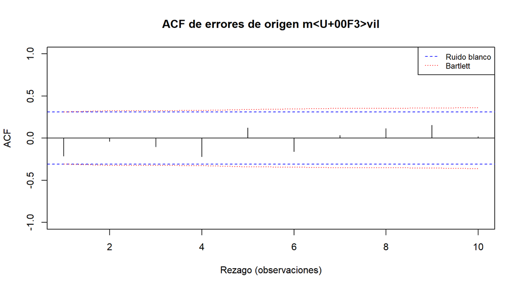

```r
# Se recuperan los datos de la ruta 1 para avanzar en paralelo por pasos.
ruta <- rutas$ruta1
serie <- ruta$serie
y <- as.numeric(serie)
s <- ruta$s
evaluacion <- evaluaciones$ruta1

# La columna elegida contiene errores fuera de muestra, uno por origen.
errores_ganador <- evaluacion$errores[, evaluacion$ganador]
m_error <- floor(length(errores_ganador) / 4)
graficar_acf(errores_ganador, m_error, "ACF de errores de origen móvil")
```

```r
mostrar_tabla(resultado_ljung(errores_ganador, m = m_error, p = 0))
```

| n | m | parametros_descontados | gl | Q | valor_p |
| --- | --- | --- | --- | --- | --- |
| 40 | 10 | 0 | 10 | 8.7342 | 0.5575 |

```r
mostrar_tabla(data.frame(
  Metodo = evaluacion$ganador, N = length(errores_ganador),
  Error_medio = mean(errores_ganador),
  RMSE = sqrt(mean(errores_ganador^2)),
  Cociente_error_medio_RMSE = mean(errores_ganador) /
    sqrt(mean(errores_ganador^2))
))
```

| Metodo | N | Error_medio | RMSE | Cociente_error_medio_RMSE |
| --- | --- | --- | --- | --- |
| Tendencia y ficticias | 40 | 0.1109 | 1.9686 | 0.0563 |

```r
# Jarque–Bera usa asimetría y curtosis calculadas con momentos de orden 2, 3 y 4.
# lower.tail = FALSE devuelve la cola superior de la chi-cuadrado con 2 gl.
if (length(errores_ganador) >= 40) {
  centrados <- errores_ganador - mean(errores_ganador)
  m2 <- mean(centrados^2)
  asimetria <- mean(centrados^3) / m2^(3 / 2)
  curtosis <- mean(centrados^4) / m2^2
  JB <- length(centrados) / 6 * (asimetria^2 + (curtosis - 3)^2 / 4)
  mostrar_tabla(data.frame(
    N = length(centrados), JB = JB, gl = 2,
    valor_p = stats::pchisq(JB, df = 2, lower.tail = FALSE)
  ))
} else {
  mostrar_tabla(data.frame(
    N = length(errores_ganador),
    Jarque_Bera = "No calculada: menos de 40 errores; criterio operativo."
  ))
}
```

| N | JB | gl | valor_p |
| --- | --- | --- | --- |
| 40 | 1.3417 | 2 | 0.5113 |

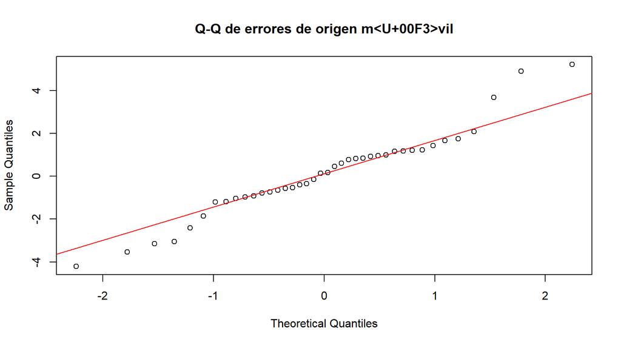

```r
# El gráfico Q-Q permite examinar visualmente la forma de los errores.
stats::qqnorm(errores_ganador, main = "Q-Q de errores de origen móvil")
stats::qqline(errores_ganador, col = "red")
```

**Ruta 1, paso 6**

- **Ljung–Box:** $H_0$ establece que no hay autocorrelación hasta el rezago 10. Como $Q=8{,}7342$ y el valor $p=0{,}5575>0{,}05$, no se rechaza $H_0$.
- **Correlograma:** No muestra autocorrelaciones significativas; los errores se comportan aproximadamente como ruido blanco.
- **Jarque–Bera:** $H_0$ supone normalidad. Como $JB=1{,}3417$ y el valor $p=0{,}5113>0{,}05$, no se rechaza la normalidad.
- **Gráfico Q-Q:** Los puntos siguen aproximadamente la recta, sin desviaciones graves de la normalidad.
- **Error medio frente al RMSE:** El error medio es **0,1109**, pequeño frente al RMSE de **1,9686**; no se observa un sesgo importante.
- **Limitaciones:** Solo se usan 40 errores y el ganador se seleccionó con la misma muestra, por lo que las pruebas tienen potencia limitada y son aproximadas.

#### Procedimiento adicional de la ruta 1: residuos de medias estacionales

```r
# Se ajustan doce medias estacionales sobre toda la serie para la comparación
# adicional solicitada. Aquí sí se trata de residuos dentro de muestra.
datos_completos <- data.frame(y = y, q = factor(cycle(serie)))
ajuste_medias <- stats::lm(y ~ q - 1, data = datos_completos)
residuos_medias <- stats::residuals(ajuste_medias)
mostrar_tabla(resultado_ljung(residuos_medias, m = 24, p = 12))
```

| n | m | parametros_descontados | gl | Q | valor_p |
| --- | --- | --- | --- | --- | --- |
| 240 | 24 | 12 | 12 | 46.0035 | 6.929e-06 |

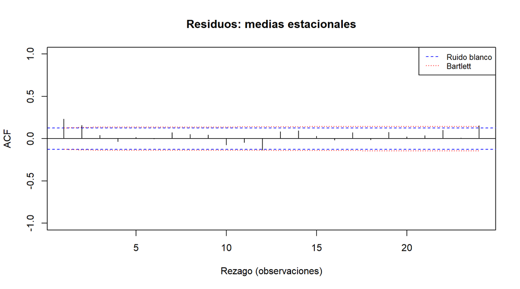

```r
graficar_acf(residuos_medias, 24, "Residuos: medias estacionales")
```

**Ruta 1, comparación adicional**

- **Comparación:** En los errores de origen móvil no se rechaza la ausencia de autocorrelación ($p=0{,}5575$); en los residuos de medias estacionales sí se rechaza ($p=6{,}929\times10^{-6}$).
- **Explicación:** El ganador incluye tendencia y estacionalidad y se evalúa fuera de muestra, mientras que las medias estacionales solo eliminan la estacionalidad y dejan dependencia temporal. Además, ambos diagnósticos usan distintos tamaños de muestra, rezagos y grados de libertad.

### Ruta 2. Consumo trimestral de gas del Reino Unido

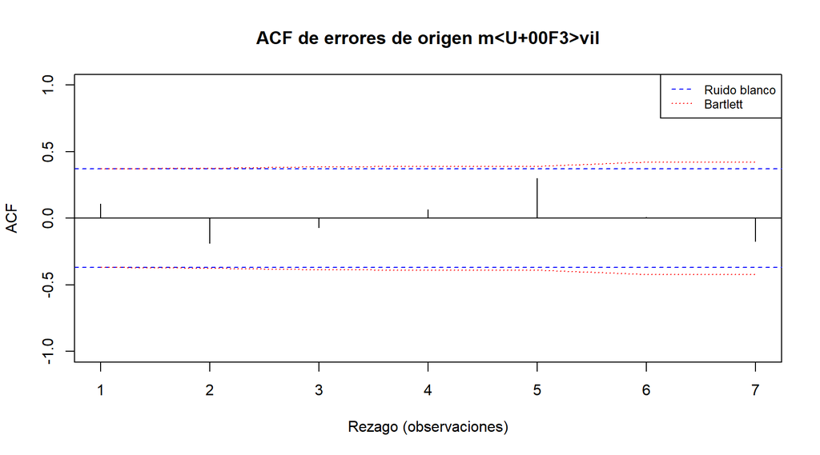

```r
# Se recuperan los datos de la ruta 2 para avanzar en paralelo por pasos.
ruta <- rutas$ruta2
serie <- ruta$serie
y <- as.numeric(serie)
s <- ruta$s
evaluacion <- evaluaciones$ruta2

# La columna elegida contiene errores fuera de muestra, uno por origen.
errores_ganador <- evaluacion$errores[, evaluacion$ganador]
m_error <- floor(length(errores_ganador) / 4)
graficar_acf(errores_ganador, m_error, "ACF de errores de origen móvil")
```

```r
mostrar_tabla(resultado_ljung(errores_ganador, m = m_error, p = 0))
```

| n | m | parametros_descontados | gl | Q | valor_p |
| --- | --- | --- | --- | --- | --- |
| 28 | 7 | 0 | 7 | 6.3239 | 0.5025 |

```r
mostrar_tabla(data.frame(
  Metodo = evaluacion$ganador, N = length(errores_ganador),
  Error_medio = mean(errores_ganador),
  RMSE = sqrt(mean(errores_ganador^2)),
  Cociente_error_medio_RMSE = mean(errores_ganador) /
    sqrt(mean(errores_ganador^2))
))
```

| Metodo | N | Error_medio | RMSE | Cociente_error_medio_RMSE |
| --- | --- | --- | --- | --- |
| HW aditivo | 28 | 0.6866 | 43.879 | 0.0156 |

```r
# Jarque–Bera usa asimetría y curtosis calculadas con momentos de orden 2, 3 y 4.
# lower.tail = FALSE devuelve la cola superior de la chi-cuadrado con 2 gl.
if (length(errores_ganador) >= 40) {
  centrados <- errores_ganador - mean(errores_ganador)
  m2 <- mean(centrados^2)
  asimetria <- mean(centrados^3) / m2^(3 / 2)
  curtosis <- mean(centrados^4) / m2^2
  JB <- length(centrados) / 6 * (asimetria^2 + (curtosis - 3)^2 / 4)
  mostrar_tabla(data.frame(
    N = length(centrados), JB = JB, gl = 2,
    valor_p = stats::pchisq(JB, df = 2, lower.tail = FALSE)
  ))
} else {
  mostrar_tabla(data.frame(
    N = length(errores_ganador),
    Jarque_Bera = "No calculada: menos de 40 errores; criterio operativo."
  ))
}
```

| N | Jarque_Bera |
| --- | --- |
| 28 | No calculada: menos de 40 errores; criterio operativo. |

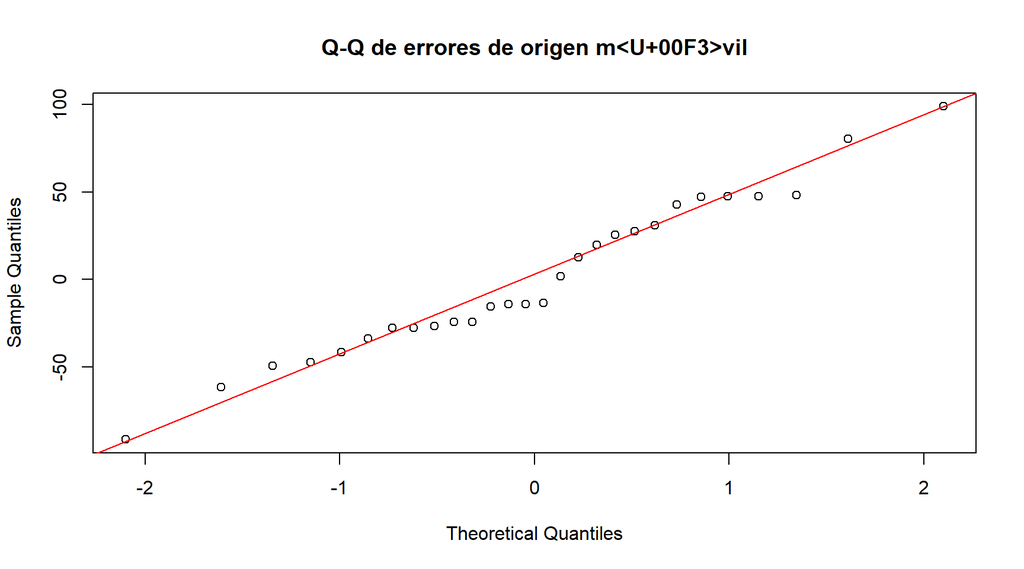

```r
# El gráfico Q-Q permite examinar visualmente la forma de los errores.
stats::qqnorm(errores_ganador, main = "Q-Q de errores de origen móvil")
stats::qqline(errores_ganador, col = "red")
```

**Ruta 2, paso 6**

- **Ljung–Box:** $H_0$ establece que no hay autocorrelación hasta el rezago 7. Como $Q=6{,}3239$ y el valor $p=0{,}5025>0{,}05$, no se rechaza $H_0$.
- **Correlograma:** No muestra autocorrelaciones significativas; los errores se comportan aproximadamente como ruido blanco.
- **Jarque–Bera:** No se calcula porque solo hay 28 errores, menos del mínimo operativo de 40.
- **Gráfico Q-Q:** Los puntos siguen aproximadamente la recta, aunque la muestra pequeña limita la evaluación de normalidad.
- **Error medio frente al RMSE:** El error medio es **0,6866**, muy pequeño frente al RMSE de **43,8790**; no se observa un sesgo importante.
- **Limitaciones:** Solo se usan 28 errores y el ganador se seleccionó con la misma muestra; por ello, las pruebas tienen poca potencia y deben interpretarse con cautela.

## Paso 7. Pronosticar un ciclo completo

### Ruta 1. Temperatura mensual de Nottingham

```r
# Se recuperan los datos de la ruta 1 para avanzar en paralelo por pasos.
ruta <- rutas$ruta1
serie <- ruta$serie
y <- as.numeric(serie)
s <- ruta$s
evaluacion <- evaluaciones$ruta1
errores_ganador <- evaluacion$errores[, evaluacion$ganador]

# Se reajusta el método seleccionado con toda la serie para proyectar s períodos.
# La banda es heurística: pronóstico +/- 1.96 desviaciones de los errores
# de horizonte uno. Se conserva su ancho para todos los horizontes.
futuros <- pronosticar_metodo(y, s, evaluacion$ganador, h = s)
desviacion_error <- stats::sd(errores_ganador)
limite_inferior <- futuros - stats::qnorm(0.975) * desviacion_error
limite_superior <- futuros + stats::qnorm(0.975) * desviacion_error
tiempo_futuro <- tail(as.numeric(time(serie)), 1) + seq_len(s) / s
pronostico_final <- data.frame(
  Horizonte = seq_len(s), Anio = floor(tiempo_futuro + 1e-8),
  Periodo = round((tiempo_futuro - floor(tiempo_futuro + 1e-8)) * s) + 1,
  Pronostico = futuros, Inferior_heuristico = limite_inferior,
  Superior_heuristico = limite_superior
)
mostrar_tabla(pronostico_final)
```

| Horizonte | Anio | Periodo | Pronostico | Inferior_heuristico | Superior_heuristico |
| --- | --- | --- | --- | --- | --- |
| 1 | 1940 | 1 | 40.2944 | 36.3931 | 44.1957 |
| 2 | 1940 | 2 | 39.7894 | 35.8881 | 43.6907 |
| 3 | 1940 | 3 | 42.7944 | 38.8931 | 46.6957 |
| 4 | 1940 | 4 | 46.8894 | 42.9881 | 50.7907 |
| 5 | 1940 | 5 | 53.1594 | 49.2581 | 57.0607 |
| 6 | 1940 | 6 | 58.6394 | 54.7381 | 62.5407 |
| 7 | 1940 | 7 | 62.4994 | 58.5981 | 66.4007 |
| 8 | 1940 | 8 | 61.1194 | 57.2181 | 65.0207 |
| 9 | 1940 | 9 | 57.0794 | 53.1781 | 60.9807 |
| 10 | 1940 | 10 | 50.0944 | 46.1931 | 53.9957 |
| 11 | 1940 | 11 | 43.1794 | 39.2781 | 47.0807 |
| 12 | 1940 | 12 | 40.1294 | 36.2281 | 44.0307 |

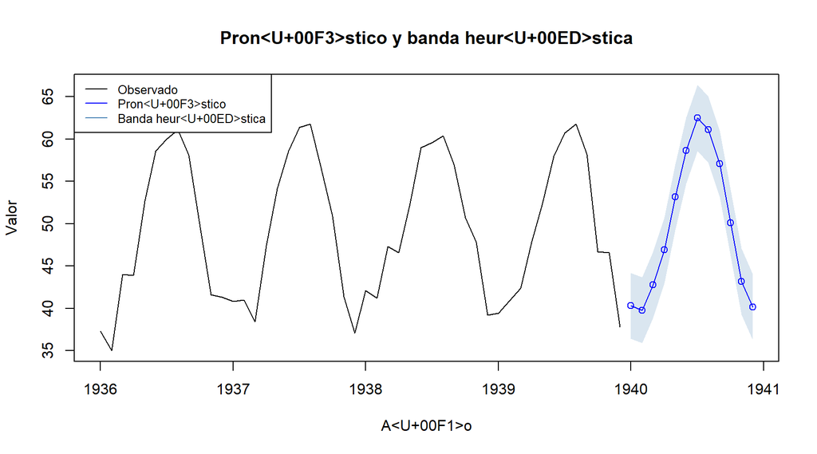

```r
# Se muestran los cuatro últimos ciclos y un ciclo futuro.
inicio <- max(1, length(y) - 4 * s + 1)
indices <- inicio:length(y)
plot(as.numeric(time(serie))[indices], y[indices], type = "l",
     xlim = range(as.numeric(time(serie))[indices], tiempo_futuro),
     ylim = range(y[indices], limite_inferior, limite_superior),
     xlab = "Año", ylab = "Valor", main = "Pronóstico y banda heurística")
polygon(c(tiempo_futuro, rev(tiempo_futuro)),
        c(limite_inferior, rev(limite_superior)),
        col = adjustcolor("steelblue", alpha.f = 0.2), border = NA)
lines(tiempo_futuro, futuros, type = "o", col = "blue")
legend("topleft", c("Observado", "Pronóstico", "Banda heurística"),
       col = c("black", "blue", "steelblue"), lty = c(1, 1, 1), cex = 0.8)
```

**Ruta 1, paso 7**

- **¿Por qué la banda es heurística?:** Se construye como pronóstico $\pm 1{,}96$ desviaciones de los errores de horizonte uno y conserva el mismo ancho. No incorpora la incertidumbre de los parámetros ni el aumento del error con el horizonte, por lo que no es un intervalo formal.
- **Interpretación, línea 1:** Para 1940 se pronostican temperaturas cercanas a **40** grados al inicio del año, con un mínimo de **39,789** en febrero.
- **Interpretación, línea 2:** La temperatura aumenta hasta alcanzar un máximo de **62,499** en julio.
- **Interpretación, línea 3:** Después disminuye gradualmente hasta **40,129** en diciembre, reproduciendo el patrón estacional anual.

### Ruta 2. Consumo trimestral de gas del Reino Unido

```r
# Se recuperan los datos de la ruta 2 para avanzar en paralelo por pasos.
ruta <- rutas$ruta2
serie <- ruta$serie
y <- as.numeric(serie)
s <- ruta$s
evaluacion <- evaluaciones$ruta2
errores_ganador <- evaluacion$errores[, evaluacion$ganador]

# Se reajusta el método seleccionado con toda la serie para proyectar s períodos.
# La banda es heurística: pronóstico +/- 1.96 desviaciones de los errores
# de horizonte uno. Se conserva su ancho para todos los horizontes.
futuros <- pronosticar_metodo(y, s, evaluacion$ganador, h = s)
desviacion_error <- stats::sd(errores_ganador)
limite_inferior <- futuros - stats::qnorm(0.975) * desviacion_error
limite_superior <- futuros + stats::qnorm(0.975) * desviacion_error
tiempo_futuro <- tail(as.numeric(time(serie)), 1) + seq_len(s) / s
pronostico_final <- data.frame(
  Horizonte = seq_len(s), Anio = floor(tiempo_futuro + 1e-8),
  Periodo = round((tiempo_futuro - floor(tiempo_futuro + 1e-8)) * s) + 1,
  Pronostico = futuros, Inferior_heuristico = limite_inferior,
  Superior_heuristico = limite_superior
)
mostrar_tabla(pronostico_final)
```

| Horizonte | Anio | Periodo | Pronostico | Inferior_heuristico | Superior_heuristico |
| --- | --- | --- | --- | --- | --- |
| 1 | 1987 | 1 | 1205.388 | 1117.819 | 1292.956 |
| 2 | 1987 | 2 | 654.165 | 566.597 | 741.734 |
| 3 | 1987 | 3 | 387.626 | 300.057 | 475.195 |
| 4 | 1987 | 4 | 823.750 | 736.181 | 911.318 |

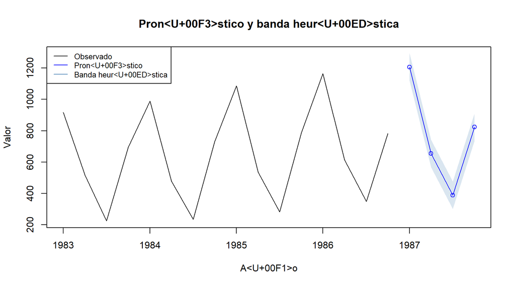

```r
# Se muestran los cuatro últimos ciclos y un ciclo futuro.
inicio <- max(1, length(y) - 4 * s + 1)
indices <- inicio:length(y)
plot(as.numeric(time(serie))[indices], y[indices], type = "l",
     xlim = range(as.numeric(time(serie))[indices], tiempo_futuro),
     ylim = range(y[indices], limite_inferior, limite_superior),
     xlab = "Año", ylab = "Valor", main = "Pronóstico y banda heurística")
polygon(c(tiempo_futuro, rev(tiempo_futuro)),
        c(limite_inferior, rev(limite_superior)),
        col = adjustcolor("steelblue", alpha.f = 0.2), border = NA)
lines(tiempo_futuro, futuros, type = "o", col = "blue")
legend("topleft", c("Observado", "Pronóstico", "Banda heurística"),
       col = c("black", "blue", "steelblue"), lty = c(1, 1, 1), cex = 0.8)
```

**Ruta 2, paso 7**

- **¿Por qué la banda es heurística?:** Se construye como pronóstico $\pm 1{,}96$ desviaciones de los errores de horizonte uno y conserva el mismo ancho. No incorpora la incertidumbre de los parámetros ni el aumento del error con el horizonte, por lo que no es un intervalo formal.
- **Interpretación, línea 1:** Para 1987 se pronostica un máximo de **1205,388** en el primer trimestre.
- **Interpretación, línea 2:** El consumo baja a **654,165** en el segundo trimestre y alcanza un mínimo de **387,626** en el tercero.
- **Interpretación, línea 3:** En el cuarto trimestre se espera una recuperación hasta **823,750**, manteniendo el patrón estacional de la serie.

## Paso 8. Contraste de tipo II frente a tipo IV (solo ruta 1)

### Ruta 1. Temperatura mensual de Nottingham

```r
# Se recuperan los datos de la ruta 1 para avanzar en paralelo por pasos.
ruta <- rutas$ruta1
serie <- ruta$serie
y <- as.numeric(serie)
s <- ruta$s

# Los dos modelos usan los mismos datos; el segundo agrega una tendencia.
# anova con test = "F" compara la reducción de suma de cuadrados residual.
datos_F <- data.frame(y = y, t = seq_along(y), q = factor(cycle(serie)))
modelo_reducido <- stats::lm(y ~ q, data = datos_F)
modelo_completo <- stats::lm(y ~ t + q, data = datos_F)
comparacion_F <- stats::anova(modelo_reducido, modelo_completo, test = "F")
pendiente <- unname(stats::coef(modelo_completo)["t"])
mostrar_tabla(data.frame(
  F = comparacion_F$F[2], valor_p = comparacion_F[["Pr(>F)"]][2],
  Pendiente_F_por_mes = pendiente, Pendiente_F_por_decada = 120 * pendiente
))
```

| F | valor_p | Pendiente_F_por_mes | Pendiente_F_por_decada |
| --- | --- | --- | --- |
| 4.9374 | 0.0273 | 0.0048 | 0.5709 |

**Ruta 1, paso 8**

- **Hipótesis:** $H_0$ establece que la pendiente temporal es cero, es decir, que al controlar la estacionalidad no existe tendencia. $H_1$ establece que la pendiente es distinta de cero.
- **Significancia y regla:** Con $\alpha=0{,}05$, se rechaza $H_0$ cuando el valor $p$ es menor que 0,05.
- **Conclusión estadística:** Como $F=4{,}9374$ y $p=0{,}0273<0{,}05$, se rechaza $H_0$. Hay evidencia estadística de una tendencia temporal en la temperatura de Nottingham después de controlar el mes del año.
- **Magnitud:** La pendiente estimada equivale a un aumento de **0,5709 grados Fahrenheit por década**.
- **Dirección conjunta:** Sí. La prueba detecta una tendencia significativa y la pendiente positiva indica que esa tendencia es de aumento.

# 4. Estación C. Auditoría

Los siguientes fragmentos son los ejemplos que deben auditarse. Se muestran sin ejecutar porque utilizan funciones y datos propios del curso. Sus defectos se dejan para el análisis de los autores.

## C.1. Bloque 1

```r
y <- creditos_consumo
p <- optimizar_holt(y, 0.05)
holt_opt <- function(yy, h) ajustar_holt(yy, p$a, p$b)$pronosticar(h)
om <- origen_movil(y, list(Holt = holt_opt), origenes = 20:40)
```

## C.2. Bloque 2

```r
b <- unname(rendimiento_bono)
rbind(`MM(4)` = medidas(b, ajustar_mm(b, 4)$yhat),
      `SES(0,2)` = medidas(b, ajustar_ses(b, 0.2)$yhat))
```

## C.3. Bloque 3

```r
yn <- as.numeric(nottem)
qn <- factor(cycle(nottem))
en <- residuals(lm(yn ~ qn - 1))
ljung_box(acf_muestral(en, 24), T = 240)
```

## C.4. Bloque 4

La afirmación del enunciado es que el método gana porque su MASE es 0.92. El numerador usa errores sobre UKgas en los orígenes 80:107, pero el denominador del ingenuo estacional se calcula sobre el entrenamiento inicial.

```r
# Esta tabla recupera la evaluación de la ruta 2 sobre los orígenes 80:107.
# No identifica el método anónimo del enunciado; aporta la comparación disponible.
mostrar_tabla(evaluaciones$ruta2$tabla)
```

| Metodo | Origenes | RMSE | MAD | MAPE_porcentaje |
| --- | --- | --- | --- | --- |
| HW aditivo | 28 | 43.8790 | 37.2344 | 7.2958 |
| HW multiplicativo | 28 | 44.1593 | 36.7177 | 6.6200 |
| Ingenuo estacional | 28 | 51.9641 | 39.9643 | 6.9240 |
| Log tendencia y ficticias | 28 | 112.1629 | 105.1092 | 22.9470 |
| Tendencia y ficticias | 28 | 189.7003 | 163.4535 | 33.1686 |

# Auditoría de bloques problemáticos — versión resumida

| Bloque | Línea problemática | Defecto | Efecto | Corrección |
| --- | --- | --- | --- | --- |
| 1 | `p <- optimizar_holt(y, 0.05)` con `y` completa | **Fuga de información**: $\alpha, \beta$ se calibran con toda la serie, no solo con el pasado de cada origen. | RMSE optimista, mejor que en producción. | Optimizar $\alpha, \beta$ **dentro** de la función, con `yy = y[1:o]`. |
| 2 | `medidas(b, ajustar_mm(b, 4)$yhat)` | $MM_t(4)$ incluye $Y_t$ (no es pronóstico); además compara **ventanas distintas** y sin el ingenuo. | MM(4) parece ganar, pero se compara un *ajuste* contra un *pronóstico*. | **Rezagar** la MM un período, igualar ventanas y añadir el **ingenuo**. |
| 3 | `ljung_box(acf_muestral(en, 24), T = 240)` sin `p` | Faltan los **12 grados de libertad** del modelo estimado. | Valor $p$ inflado (usa $\chi^2_{24}$ en vez de $\chi^2_{12}$). | Usar `p = 12` (número de parámetros estimados). |
| 4 | MASE $= 0{,}92$ con denominador de `y[1:80]` | Numerador y denominador de **tramos distintos** de una serie que se multiplica por $\approx 6$. | Razón sin sentido: mezcla calidad del método con crecimiento de la serie. | Ingenuo calculado sobre los **mismos orígenes 80:107** (da MAD $= 0{,}93$). |

# 5. Estación D. Cuatro demostraciones

## D.1. Actualización de la media móvil

Demostrar la identidad:

$$MM_{t+1}(k)=MM_t(k)+\frac{Y_{t+1}-Y_{t+1-k}}{k}.$$

# D.1 — Demostración

Por definición, para $t \ge k$:

$$MM_{t+1}(k) = \frac{1}{k}\sum_{i=0}^{k-1} Y_{t+1-i}
= \frac{1}{k}\left( Y_{t+1} + Y_t + \cdots + Y_{t+2-k} \right),$$

$$MM_t(k) = \frac{1}{k}\sum_{i=0}^{k-1} Y_{t-i}
= \frac{1}{k}\left( Y_t + Y_{t-1} + \cdots + Y_{t+1-k} \right).$$

Las dos sumas comparten exactamente los $k-1$ términos $Y_t, \dots, Y_{t+2-k}$. Restando, todo lo común se cancela y sobreviven el dato que entra ($Y_{t+1}$) y el que sale ($Y_{t+1-k}$):

$$MM_{t+1}(k) - MM_t(k) = \frac{1}{k}\left( Y_{t+1} - Y_{t+1-k} \right)
\quad \Longrightarrow \quad
MM_{t+1}(k) = MM_t(k) + \frac{Y_{t+1} - Y_{t+1-k}}{k}.
\;\blacksquare$$

## Costo de actualizar frente a recalcular

Actualizar cuesta **tres operaciones** (una resta, una división y una suma), **independientes de $k$**. Recalcular desde cero cuesta $k-1$ sumas y una división, es decir $\mathcal{O}(k)$.

- Con $k = 6$ la diferencia es modesta.
- Con una ventana de, por ejemplo, $250$ observaciones el ahorro es de casi **dos órdenes de magnitud**, y es lo que permite actualizar una media móvil en tiempo real guardando solo el valor anterior y el dato que sale de la ventana.

```r
media_movil <- function(y, k) {
  n <- length(y); mm <- rep(NA_real_, n)
  for (t in k:n) mm[t] <- mean(y[(t - k + 1):t])
  mm
}
set.seed(2026); y <- rnorm(60, 10, 2); k <- 6
mm  <- media_movil(y, k)
izq <- mm[(k + 1):60]
der <- mm[k:59] + (y[(k + 1):60] - y[1:(60 - k)]) / k
max(abs(izq - der))
```

[1] 1.77636e-15 [1] 1.77636e-15

La diferencia máxima entre ambos lados es del orden de 10 − 15 , el error de redondeo de punto flotante: la identidad queda confirmada numéricamente.

## D.2. Recursión del suavizamiento exponencial

Partir de la suma infinita y demostrar:

$$\widehat Y_{t+1}=\alpha Y_t+(1-\alpha)\widehat Y_t.$$

# D.2 — Demostración

Parta de

$$\hat{Y}_{t+1} = \alpha \sum_{i \ge 0} (1 - \alpha)^i \, Y_{t-i}$$

y separe el primer sumando ($i = 0$) del resto:

$$\hat{Y}_{t+1} = \alpha Y_t + \alpha \sum_{i \ge 1} (1 - \alpha)^i \,
Y_{t-i}.$$

En la suma restante, el cambio de índice $j = i - 1$ da

$$\alpha \sum_{i \ge 1} (1 - \alpha)^i \, Y_{t-i}
= \alpha \sum_{j \ge 0} (1 - \alpha)^{j+1} \, Y_{(t-1)-j}
= (1 - \alpha) \underbrace{\alpha \sum_{j \ge 0} (1 - \alpha)^j \,
Y_{(t-1)-j}}_{=\;\hat{Y}_t \text{ (misma definición evaluada en }
t-1\text{)}}.$$

Por lo tanto

$$\hat{Y}_{t+1} = \alpha Y_t + (1 - \alpha) \hat{Y}_t. \quad \blacksquare$$

Nótese además que los pesos suman uno,

$$\alpha \sum_{i \ge 0} (1 - \alpha)^i = \alpha \cdot \frac{1}{1 - (1 -
\alpha)} = 1,$$

así que $\hat{Y}_{t+1}$ es un promedio ponderado legítimo del pasado, y la convergencia de la suma infinita está garantizada porque $|1 - \alpha| < 1$.

## Valores a guardar y operaciones

- La **forma de suma** exige conservar todo el pasado ($t$ valores en el instante $t$) y cuesta $\mathcal{O}(t)$ operaciones para producir un pronóstico, un costo que **crece con el tiempo**.
- La **forma recursiva** solo necesita guardar dos números — el dato más reciente $Y_t$ y el pronóstico anterior $\hat{Y}_t$ — y cuesta **tres operaciones** (una multiplicación, un complemento y una suma) por pronóstico nuevo, sin importar cuán larga sea la historia.

Es la razón de que el suavizamiento exponencial fuera un método de referencia en control de inventarios mucho antes de que la memoria de cómputo fuera barata.

```r
ajustar_ses <- function(y, a) {
  n <- length(y); yhat <- rep(NA_real_, n); yhat[2] <- y[1]
  for (t in 3:n) yhat[t] <- a * y[t - 1] + (1 - a) * yhat[t - 1]
  yhat
}
a  <- 0.3
yh <- ajustar_ses(y, a)   # y proviene del chunk D.1
suma <- sapply(3:60, function(t) {
  i <- 0:(t - 3)
  a * sum((1 - a)^i * y[t - 1 - i]) + (1 - a)^(t - 2) * y[1]
})
max(abs(yh[3:60] - suma))
```

[1] 1.77636e-15

Sea $Y_t=\beta_0+\beta_1t+\varepsilon_t$, con $\varepsilon_t\sim RB(0,\sigma^2)$, y $Z_t=Y_t-Y_{t-1}$.

# D.3 — Demostración

## a) Diferenciar una tendencia lineal elimina el nivel y convierte la pendiente en la media

Sustituyendo $Y_t = \beta_0 + \beta_1 t + \varepsilon_t$:

$$\begin{aligned}
Z_t = Y_t - Y_{t-1}
&= \left( \beta_0 + \beta_1 t + \varepsilon_t \right)
- \left( \beta_0 + \beta_1 (t-1) + \varepsilon_{t-1} \right) \\
&= \beta_1 + \left( \varepsilon_t - \varepsilon_{t-1} \right)
= \beta_1 + u_t,
\end{aligned}$$

con $u_t = \varepsilon_t - \varepsilon_{t-1}$. Como $\mathbb{E}(u_t) = 0$ para todo $t$, $\mathbb{E}(Z_t) = \beta_1$ es constante, libre de $t$: $\{Z_t\}$ es **estacionaria en media**. Diferenciar eliminó el nivel $\beta_0$ y convirtió la pendiente en la nueva media.

## b) La diferencia de ruido blanco es una MA(1) con $\theta = -1$

Con $\varepsilon_t \sim \mathrm{RB}(0, \sigma^2)$ (media cero, varianza $\sigma^2$, incorrelacionado a todo rezago):

$$\mathbb{E}(u_t) = \mathbb{E}(\varepsilon_t) -
\mathbb{E}(\varepsilon_{t-1}) = 0,$$

$$\operatorname{Var}(u_t)
= \operatorname{Var}(\varepsilon_t) +
\operatorname{Var}(\varepsilon_{t-1})
- 2\operatorname{Cov}(\varepsilon_t, \varepsilon_{t-1})
= \sigma^2 + \sigma^2 - 0
= 2\sigma^2.$$

**Caso $h = 1$:**

$$\begin{aligned}
\operatorname{Cov}(u_t, u_{t-1})
&= \mathbb{E}\!\left[ (\varepsilon_t -
\varepsilon_{t-1})(\varepsilon_{t-1} - \varepsilon_{t-2}) \right] \\
&= \underbrace{\mathbb{E}(\varepsilon_t \varepsilon_{t-1})}_{0}
- \underbrace{\mathbb{E}(\varepsilon_t \varepsilon_{t-2})}_{0}
- \underbrace{\mathbb{E}(\varepsilon_{t-1}^2)}_{\sigma^2}
+ \underbrace{\mathbb{E}(\varepsilon_{t-1} \varepsilon_{t-2})}_{0}
= -\sigma^2.
\end{aligned}$$

El único término que sobrevive es $-\mathbb{E}(\varepsilon_{t-1}^2)$: $\varepsilon_{t-1}$ aparece con signo $+$ en $u_{t-1}$ y con signo $-$ en $u_t$.

**Caso $h \ge 2$:** los índices $\{t, t-1\}$ y $\{t-h, t-h-1\}$ son disjuntos, así que los cuatro productos cruzados tienen esperanza cero:

$$\operatorname{Cov}(u_t, u_{t-h}) = 0, \qquad h \ge 2.$$

## c) $\{u_t\}$ no es ruido blanco: la firma de la sobrediferenciación

$\{u_t\}$ **no es ruido blanco**: tiene media cero y varianza constante, pero

$$\operatorname{Cov}(u_t, u_{t-1}) = -\sigma^2 \neq 0.$$

Su autocorrelación de orden uno es

$$\rho_u(1) = \frac{-\sigma^2}{2\sigma^2} = -\tfrac{1}{2},$$

negativa porque cada $\varepsilon_{t-1}$ se usa dos veces con signos opuestos: un $u_{t-1}$ grande (por un $\varepsilon_{t-1}$ alto) empuja a $u_t$ hacia lo negativo. Es la **sobrediferenciación clásica**: diferenciar una tendencia lineal induce una MA(1) con $\theta = -1$, y $|\rho_u(1)| = 1/2$ es, de hecho, el máximo posible para cualquier MA(1).

## ¿Estacionariedad en media sin ruido blanco? Sí.

La **estacionariedad en media** solo exige que $\mathbb{E}(Z_t)$ no dependa de $t$; ser **ruido blanco** exige además incorrelación a todos los rezagos. Aquí $\{Z_t\}$ cumple lo primero y no lo segundo.

La consecuencia práctica: tras diferenciar una serie con tendencia determinística, el correlograma de la diferencia **no debería salir limpio** — un $\rho_u(1) \approx -0{,}5$ es la firma de haber diferenciado algo que ya era estacionario alrededor de una recta.

## D.4. Ficticias y medias estacionales

Demostrar que los coeficientes de la regresión estacional sin intercepto son los promedios de cada estación.

**ESCRIBIR AQUÍ — D.4**

Sea $X$ la matriz $n \times r$ de ficticias (con $n$ ciclos completos), $x_{tj} = 1$ si la observación $t$ pertenece a la estación $j$ y $0$ en otro caso. La entrada $(j, l)$ de $X^\top X$ es

$$(X^\top X)_{jl} = \sum_{t=1}^{nr} x_{tj} \, x_{tl}.$$

Aquí se usa que **cada fila de $X$ tiene exactamente un uno**: si $j \ne l$ no existe ningún $t$ con $x_{tj} = x_{tl} = 1$ (una observación no puede pertenecer a dos estaciones a la vez), así que $(X^\top X)_{jl} = 0$. Si $j = l$, $x_{tj}^2 = x_{tj}$ y la suma cuenta cuántas observaciones caen en la estación $j$: con $n$ ciclos completos, exactamente $n$. Por lo tanto

$$X^\top X = n \, I_r
\qquad \Longrightarrow \qquad
(X^\top X)^{-1} = \frac{1}{n} \, I_r$$

— la **ortogonalidad de las columnas**, consecuencia directa de esa propiedad de las filas, es lo que permite invertir sin esfuerzo.

Por otro lado, la componente $j$ de $X^\top Y$ es

$$(X^\top Y)_j = \sum_{t} x_{tj} \, Y_t = \sum_{t \in \text{estación } j}
Y_t.$$

Combinando ambos resultados,

$$\hat{\beta} = (X^\top X)^{-1} X^\top Y
= \frac{1}{n} \left( \sum_{t \in 1} Y_t, \, \dots, \, \sum_{t \in r} Y_t
\right)^\top
\quad \Longrightarrow \quad
\hat{\beta}_j = \frac{1}{n} \sum_{t \in \text{estación } j} Y_t =
\bar{S}_j. \quad \blacksquare$$

## Caso explícito, $r = 4$ estaciones y $n = 4$ ciclos

$$X^\top X =
\begin{pmatrix}
4 & 0 & 0 & 0 \\
0 & 4 & 0 & 0 \\
0 & 0 & 4 & 0 \\
0 & 0 & 0 & 4
\end{pmatrix}
= 4 \, I_4,$$

$$X^\top Y =
\begin{pmatrix}
Y_1 + Y_5 + Y_9 + Y_{13} \\
Y_2 + Y_6 + Y_{10} + Y_{14} \\
Y_3 + Y_7 + Y_{11} + Y_{15} \\
Y_4 + Y_8 + Y_{12} + Y_{16}
\end{pmatrix}.$$

## Dos consecuencias que el taller viene usando sin volver a probarlas

1. Los coeficientes de un modelo `lm(y ~ q - 1)` **no cambian** si se elimina o añade una estación distinta: las columnas son ortogonales, sin colinealidad entre ellas.
2. El modelo de “medias estacionales” del paso 4 de la Estación B es, literalmente, “**calcule el promedio de cada mes o trimestre por separado**” — con todas las limitaciones que eso conlleva, como se vio en la comparación adicional de la ruta 1.

## Verificación numérica

```r
# y_q contiene cuatro ciclos completos de una serie con cuatro estaciones.
# q identifica la estación de cada observación y X construye sus ficticias.
y_q <- c(1.5, 4.3, 8.9, 12.5, 1.8, 4.5, 9.0, 12.1,
         1.2, 4.6, 8.1, 12.9, 1.9, 5.1, 8.6, 13.2)
q <- factor(rep(1:4, 4))
X <- stats::model.matrix(~ q - 1)

# rbind coloca en filas los coeficientes de la regresión y las medias directas.
# La igualdad de ambas filas verifica que cada coeficiente es una media estacional.
rbind(
  Coeficientes_lm = stats::coef(stats::lm(y_q ~ q - 1)),
  Medias_estacionales = tapply(y_q, q, mean)
)
```

```
                 q1    q2   q3     q4
```

Coeficientes_lm 1.6 4.625 8.65 12.675 Medias_estacionales 1.6 4.625 8.65 12.675

```r
# crossprod(X) calcula X transpuesta por X sin escribir la transpuesta a mano.
# El resultado debe ser 4 por la matriz identidad porque hay cuatro ciclos.
crossprod(X)
```

q1 q2 q3 q4 q1 4 0 0 0 q2 0 4 0 0 q3 0 0 4 0 q4 0 0 0 4

```r
# crossprod(X, y_q) calcula X transpuesta por Y.
# La segunda fila suma directamente las observaciones de cada estación.
rbind(
  `X transpuesta por Y` = as.vector(crossprod(X, y_q)),
  Sumas_por_estacion = tapply(y_q, q, sum)
)
```

```
                  1    2    3    4
```

X transpuesta por Y 6.4 18.5 34.6 50.7 Sumas_por_estacion 6.4 18.5 34.6 50.7

# 6. Cierre: autoevaluación

# Preguntas de cierre conceptual

**¿Qué distingue en el correlograma una serie de tipo II de una de tipo IV?**

En la de tipo II los picos en $s, 2s, 3s, \dots$ se mantienen sin decaer y los rezagos intermedios son negativos y simétricos (oscila alrededor de cero); en la de tipo IV esos mismos picos aparecen montados sobre un decaimiento lento positivo y los valles intermedios no bajan de cero. Ejemplos: `nottem` con $r_6 = -0{,}88$ (tipo II puro), `UKgas` con $r_6 = 0{,}13$ (tipo IV con pedestal positivo).

**¿Por qué el MSE dentro de muestra no sirve para elegir entre modelos anidados?**

Porque la suma de cuadrados residual **nunca sube** al añadir regresores: el modelo grande siempre gana, aunque el parámetro extra solo esté ajustando ruido. Elegir por MSE dentro de muestra es elegir siempre el modelo más grande. Hace falta o una prueba que penalice el parámetro (la $F$ del paso 8) o una evaluación fuera de muestra (el origen móvil).

**¿Cuál es la única línea de `origen_movil()` que impide la fuga de información?**

```r
res[i, j] <- metodos[[j]](y[1:o], h)
```

El corte `y[1:o]`, que entrega al método únicamente el pasado de su propio origen. Y solo protege si **todo** —parámetros incluidos— se estima dentro de esa llamada; el bloque 1 de la auditoría es precisamente una fuga que esquiva esta línea.

**¿Por qué una serie puede ser estacionaria en media sin que sus incrementos sean ruido blanco?**

Porque la estacionariedad en media solo exige que $\mathbb{E}(Z_t)$ no dependa de $t$, mientras que el ruido blanco exige además incorrelación a todos los rezagos. En D.3, $Z_t = \beta_1 + u_t$ tiene media constante $\beta_1$ pero $\rho_u(1) = -1/2$.

**¿Qué se reporta junto con un pronóstico, además del número?**

Una medida de incertidumbre (banda o intervalo) con su naturaleza declarada —heurística o probabilística—, el horizonte y el origen a los que corresponde, el método usado y su desempeño frente a un referente ingenuo sobre los mismos orígenes, y una interpretación en las unidades del problema para quien va a tomar la decisión.

# Referencias de implementación

- Enunciado: *Taller de la Clase 6*, Juan Pablo Valencia Arango, semestre 2026-II.
- [R stats: HoltWinters](https://stat.ethz.ch/R-manual/R-devel/library/stats/html/HoltWinters.html).
- [R stats: predicción de HoltWinters](https://stat.ethz.ch/R-manual/R-devel/library/stats/html/predict.HoltWinters.html).
- [R stats: Box.test](https://stat.ethz.ch/R-manual/R-devel/library/stats/html/box.test.html).
- [R stats: lm](https://stat.ethz.ch/R-manual/R-devel/library/stats/html/lm.html).
- [R stats: comparación de modelos lineales](https://stat.ethz.ch/R-manual/R-devel/library/stats/html/anova.lm.html).

FIN